# Mixed models excercises part 4

Epidemiology and Big Data

Rebecca Stellato

Before we get started, we’ll first load a few packages we will need for our analysis. Install them if you do not have them installed yet.

```r
# load packages
library(lme4)
library(mlmRev)
```

## Technical issues in mixed models

### Exercise 1

This exercise is about contraception use of women in Bangladesh. The dataset Contraception is located in the package **mlmRev**. Function `glmer()` that is needed to fit the GLMMs is located in the package `lme4`. To make the data available and get a description of the data:

```r
data(Contraception)
help(Contraception)
```

1. The variable livch is a factor variable containing the number of living children a woman has at the time of the study, which could be used to explain the use of contraceptives. Hint: you can use Contraception$livch to access the column livch in the dataset Contraception. Do you think this coding is a wise choice? Would it have been better to use the exact number of children?

```r
summary(Contraception$livch)
```

```
##   0   1   2  3+
## 530 356 305 743
```

Variable livch is a categorical variable containing the number of living children a woman has at the time of the study, which could be used to explain the use of contraceptives. In general, collapsing multiple catogories, as happend here with the 3+ group, loses information.

2. age is the only continuous variable that is used, examine its distribution using the boxplot() function. Try the summary() function too. Does the distribution of age appear to be symmetrical? Does it need to be?

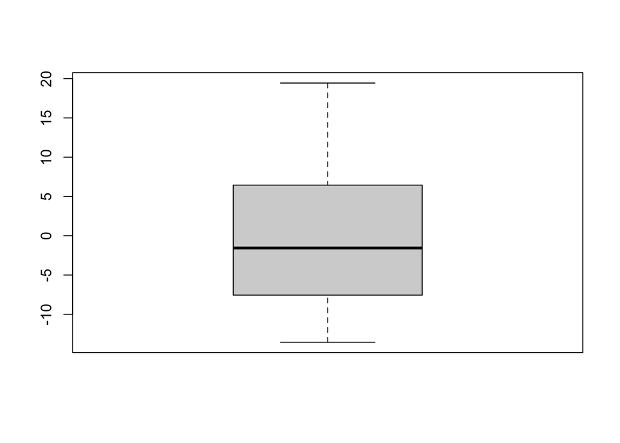

```r
boxplot(Contraception$age)
```

```r
summary(Contraception$age)
```

```
##       Min.    1st Qu.     Median       Mean    3rd Qu.       Max.
## -13.560000  -7.559900  -1.559900   0.002198   6.440000  19.440000
```

The distribution looks symetrical. It does not need to be, the assumption of normality has to do with the residuals in regression and if that assumption is violated, the *p*-values cannot be trusted.

3. Explore the dataset by examining different rows, for instance Contraception[1:10,] shows the first 10 rows, Contraception[100:110,] shows rows 100 to 110.

```r
Contraception[1:10,] #shows the first 10 rows
```

```
##    woman district use livch      age urban
## 1      1        1   N    3+  18.4400     Y
## 2      2        1   N     0  -5.5599     Y
## 3      3        1   N     2   1.4400     Y
## 4      4        1   N    3+   8.4400     Y
## 5      5        1   N     0 -13.5590     Y
## 6      6        1   N     0 -11.5600     Y
## 7      7        1   N    3+  18.4400     Y
## 8      8        1   N    3+  -3.5599     Y
## 9      9        1   N     1  -5.5599     Y
## 10    10        1   N    3+   1.4400     Y
```

```r
Contraception[100:110,] #shows rows 100-110
```

```
##     woman district use livch      age urban
## 100   100        1   N     2  10.4400     N
## 101   101        1   N    3+   2.4400     N
## 102   102        1   N     2  -3.5599     N
## 103   103        1   N    3+   0.4400     N
## 104   104        1   N    3+  16.4400     N
## 105   105        1   N     1   4.4400     N
## 106   106        1   N    3+  12.4400     N
## 107   107        1   N    3+   8.4400     N
## 108   108        1   N    3+  18.4400     N
## 109   109        1   N     0 -13.5590     N
## 110   110        1   N     1 -11.5590     N
```

Now we make some tables to examine the relationship between the use of contraceptives and different factors using the `table()` command. For more information on `table()`, use `?table`. For proportions you can look into the `prop.table()` argument.

4. Make a cross tabulation of urban and use. What’s the percentage of women in rural areas using contraception? And what’s the percentage of women in urban areas using contraception?

```r
with(Contraception, table(urban, use))
```

```
##      use
## urban   N   Y
##     N 903 469
##     Y 272 290
```

```r
# check ?with to understand this or
# similar: table(Contraception$urban, Contraception$use)
prop.table(x = with(Contraception, table(urban, use)),
           margin = 1) # get proportions over rows of the table
```

```
##      use
## urban         N         Y
##     N 0.6581633 0.3418367
##     Y 0.4839858 0.5160142
```

In urban areas the percentage of contraception use seems to be higher, 52% versus 34%

5. Examine the cross tabulation of livch and use. Does there seem to be a relationship between the number of children and the use of contraception?

```r
with(Contraception, table(livch, use))
```

```
##      use
## livch   N   Y
##    0  397 133
##    1  192 164
##    2  158 147
##    3+ 428 315
```

```r
prop.table(x = with(Contraception, table(livch, use)),
           margin = 1) # get proportions over rows of the table
```

```
##      use
## livch         N         Y
##    0  0.7490566 0.2509434
##    1  0.5393258 0.4606742
##    2  0.5180328 0.4819672
##    3+ 0.5760431 0.4239569
```

Not having kids seems to be associated with lower numbers of contraception use, 25% versus 40+% for the categories that belong to having kids.

6. Does the use of contraception seem to differ between districts in this sample?

```r
with(Contraception, table(district, use))
```

```
##         use
## district  N  Y
##       1  87 30
##       2  13  7
##       3   0  2
##       4  15 15
##       5  25 14
##       6  46 19
##       7  13  5
##       8  23 14
##       9  16  7
##       10 12  1
##       11 21  0
##       12 19 10
##       13 14 10
```

[output cut: 47 more lines]

```r
prop.table(x = with(Contraception, table(district, use)),
           margin = 1) # get proportions over rows of the table
```

```
##         use
## district          N          Y
##       1  0.74358974 0.25641026
##       2  0.65000000 0.35000000
##       3  0.00000000 1.00000000
##       4  0.50000000 0.50000000
##       5  0.64102564 0.35897436
##       6  0.70769231 0.29230769
##       7  0.72222222 0.27777778
##       8  0.62162162 0.37837838
##       9  0.69565217 0.30434783
##       10 0.92307692 0.07692308
##       11 1.00000000 0.00000000
##       12 0.65517241 0.34482759
##       13 0.58333333 0.41666667
```

[output cut: 47 more lines]

There seems to be variation between the districts.

We will fit ordinary logistic regression models to predict contraception use as a function of the number of children, age, and whether women live in urban or rural areas.

7. Fit a standard logistic model for use, regressed on main effects of livch, age and urban. This can be done using the `glm()` function. Don’t forget to specify the `family` argument. Examine the coefficients using summary(mod0). What meaning does for instance the coefficient for age have? Is the effect of age linear? (Make a table of proportions of contraceptive use against age, and make an appropriate plot.)

```r
mod0 <- glm(use ~  livch + age + urban, family = binomial, data = Contraception)
summary(mod0)
```

```
##
## Call:
## glm(formula = use ~ livch + age + urban, family = binomial, data = Contraception)
##
## Deviance Residuals:
##     Min       1Q   Median       3Q      Max
## -1.5170  -0.9994  -0.6972   1.2772   1.9635
##
## Coefficients:
##              Estimate Std. Error z value Pr(>|z|)
## (Intercept) -1.568044   0.126229 -12.422  < 2e-16 ***
## livch1       1.059186   0.151954   6.970 3.16e-12 ***
## livch2       1.287805   0.167241   7.700 1.36e-14 ***
## livch3+      1.216385   0.170593   7.130 1.00e-12 ***
## age         -0.023995   0.007536  -3.184  0.00145 **
## urbanY       0.797181   0.105186   7.579 3.49e-14 ***
## ---
## Signif. codes:  0 '***' 0.001 '**' 0.01 '*' 0.05 '.' 0.1 ' ' 1
##
## (Dispersion parameter for binomial family taken to be 1)
##
##     Null deviance: 2590.9  on 1933  degrees of freedom
## Residual deviance: 2456.7  on 1928  degrees of freedom
## AIC: 2468.7
##
## Number of Fisher Scoring iterations: 4
```

The log odds contraception use change with -0.02 for each unit of age.

```r
#put table with row proportions (i.e. margin=1) in object pt and show ("print") the results
print(pt <- with(Contraception, prop.table(table(age,use),margin=1)))
```

```
##          use
## age               N         Y
##   -13.56  0.8666667 0.1333333
##   -13.559 0.7931034 0.2068966
##   -12.56  0.7692308 0.2307692
##   -12.559 0.7659574 0.2340426
##   -11.56  0.8888889 0.1111111
##   -11.559 0.7945205 0.2054795
##   -10.56  0.6250000 0.3750000
##   -10.559 0.6760563 0.3239437
##   -9.56   0.5000000 0.5000000
##   -9.5599 0.7126437 0.2873563
##   -8.56   0.0000000 1.0000000
##   -8.5599 0.6266667 0.3733333
##   -7.56   0.7500000 0.2500000
##   -7.5599 0.5797101 0.4202899
##   -6.56   1.0000000 0.0000000
##   -6.5599 0.6060606 0.3939394
##   -5.56   0.8750000 0.1250000
##   -5.5599 0.5866667 0.4133333
##   -4.56   0.5000000 0.5000000
##   -4.5599 0.5606061 0.4393939
##   -3.56   0.8571429 0.1428571
##   -3.5599 0.4716981 0.5283019
##   -2.56   0.5000000 0.5000000
##   -2.5599 0.5066667 0.4933333
##   -1.56   0.7142857 0.2857143
##   -1.5599 0.5068493 0.4931507
##   -0.56   0.6666667 0.3333333
##   -0.5599 0.3943662 0.6056338
##   0.44    0.5465116 0.4534884
##   1.44    0.5081967 0.4918033
##   2.44    0.4852941 0.5147059
##   3.44    0.5600000 0.4400000
##   4.44    0.4482759 0.5517241
##   5.44    0.5625000 0.4375000
##   6.44    0.6037736 0.3962264
##   7.44    0.3157895 0.6842105
##   8.44    0.6315789 0.3684211
##   9.44    0.4687500 0.5312500
##   10.44   0.5925926 0.4074074
##   11.44   0.6764706 0.3235294
##   12.44   0.5000000 0.5000000
##   13.44   0.5925926 0.4074074
##   14.4399 1.0000000 0.0000000
##   14.44   0.5666667 0.4333333
##   15.44   0.8333333 0.1666667
##   16.44   0.8064516 0.1935484
##   17.44   0.7714286 0.2285714
##   18.44   0.8055556 0.1944444
##   19.4399 0.0000000 1.0000000
##   19.44   0.9000000 0.1000000
```

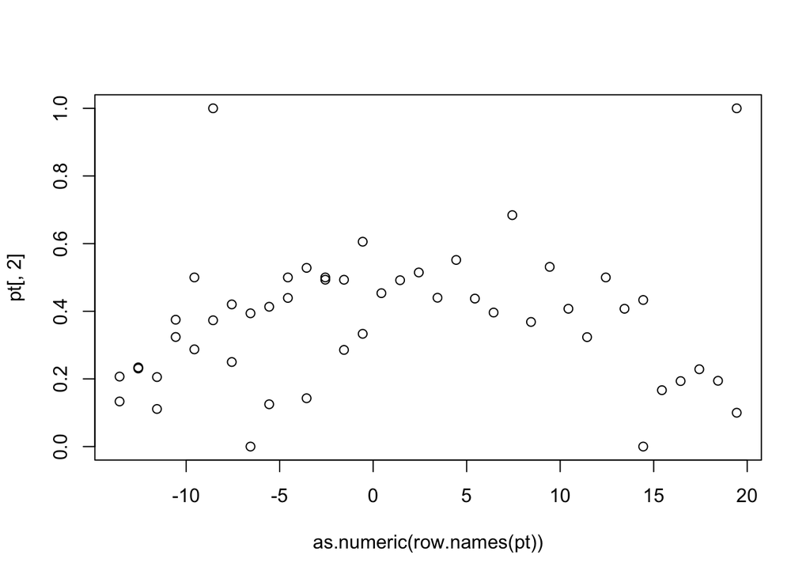

```r
#plot proportion of use vs age
plot(as.numeric(row.names(pt)),pt[,2])
```

There seems to be a quadratic relationship of contraception use with age

8. Adapt the previous model by adding a quadratic age component, note this can be done directly in the `glm()` model specification using the `I()` function. Look at the results. Based on the Wald p-value of age2, did the model improve significantly? And if you compare the AIC’s?

```r
mod1 <- glm(use ~  livch + age + I(age^2) + urban, family = binomial, data = Contraception)
summary(mod1)
```

```
##
## Call:
## glm(formula = use ~ livch + age + I(age^2) + urban, family = binomial,
##     data = Contraception)
##
## Deviance Residuals:
##     Min       1Q   Median       3Q      Max
## -1.4738  -1.0369  -0.6683   1.2401   1.9765
##
## Coefficients:
##               Estimate Std. Error z value Pr(>|z|)
## (Intercept) -0.9499521  0.1560118  -6.089 1.14e-09 ***
## livch1       0.7831128  0.1569096   4.991 6.01e-07 ***
## livch2       0.8549040  0.1783573   4.793 1.64e-06 ***
## livch3+      0.8060251  0.1784817   4.516 6.30e-06 ***
## age          0.0045837  0.0089084   0.515    0.607
## I(age^2)    -0.0042865  0.0007002  -6.122 9.23e-10 ***
## urbanY       0.7680975  0.1061916   7.233 4.72e-13 ***
## ---
## Signif. codes:  0 '***' 0.001 '**' 0.01 '*' 0.05 '.' 0.1 ' ' 1
##
## (Dispersion parameter for binomial family taken to be 1)
##
##     Null deviance: 2590.9  on 1933  degrees of freedom
## Residual deviance: 2417.7  on 1927  degrees of freedom
## AIC: 2431.7
##
## Number of Fisher Scoring iterations: 4
```

Age^2 has a significant Wald p-value, which implies that we can reject the null hypothesis that age^2 has a zero effect.

```r
AIC(mod0, mod1)
```

```
##      df      AIC
## mod0  6 2468.729
## mod1  7 2431.659
```

Based on the AIC values, we would prefer the use of the model with age^2 as predictor.

1. Now fit a logistic model for use, regressed on main effects of livch, age, I(age^2) and urban, and with a random intercept for each district. For this, use the `glmer()` function. Examine the fixed coefficients of mod2, compare these to the coefficients of mod1.

```r
mod2 <- glmer(use ~ livch + age + I(age^2) + urban + (1 | district), family = binomial, data = Contraception)
```

```
## Warning in checkConv(attr(opt, "derivs"), opt$par, ctrl = control$checkConv, :
## Model failed to converge with max|grad| = 0.00584038 (tol = 0.002, component 1)
```

```
## Warning in checkConv(attr(opt, "derivs"), opt$par, ctrl = control$checkConv, : Model is nearly unidentifiable: very large eigenvalue
##  - Rescale variables?
```

Note that you get a warning messgae about convergence. There are multiple ways to solve this. One of them is by using the internet to find a solution. If you go to google and insert the query `glmer convergence error solve`, your first hit will be an answer on the `stackexchange` website. This is often a good source of information. See [here](https://stats.stackexchange.com/questions/164457/r-glmer-warnings-model-fails-to-converge-model-is-nearly-unidentifiable). Inserting the solution gives us the following:

```r
mod2 <- glmer(use ~ livch + age + I(age^2) + urban + (1 | district), family = binomial, data = Contraception,
              control=glmerControl(optimizer="bobyqa",optCtrl=list(maxfun=2e5)))
```

```
## Warning in checkConv(attr(opt, "derivs"), opt$par, ctrl = control$checkConv, : Model is nearly unidentifiable: very large eigenvalue
##  - Rescale variables?
```

Note how we got rid of the error about convergence, but we still have an error about near unidentifiability which suggests to rescale the variables. We did get convergence now, so let us continue.

10. The AIC can again be obtained from each model using the summary() function or directly using the `AIC()` fucntion. Based on the AIC, do you prefer mod1 or mod2?

```r
AIC(mod1, mod2)
```

```
##      df      AIC
## mod1  7 2431.659
## mod2  8 2388.729
```

AIC of mod1 is 2431.7, AIC of mod2 is 2388.7 (at the top of the output). Based on this, mod2 is preferable.

11. We can also use a likelihood ratio test to compare mod1 and mod2. Why is the p-value divided by 2? Why is degfr equal to 1? Based on the likelihood ratio test, do you prefer mod1 or mod2?

```r
d1 <- as.numeric(-2*logLik(mod1)) #is the -2LL for mod1
d2 <- as.numeric(-2*logLik(mod2)) #is the -2LL for mod2
ldif <- d1 - d2 #is the -2LL difference
degfr <- 1 #difference in the number of parameters
pchisq(ldif, degfr, lower.tail = FALSE)/2 #to compute the p-value
```

```
## [1] 1.020941e-11
```

The p-value is divided by two because the extra parameter of mod2 (as compared to mod1) is a variance parameter which can only be positive, so we want to test one-sidedly. degfr is one because mod2 has one extra parameter. The -2LL of mod2 is significantly closer to 0 (p = 1.02e-11 << 0.05), therefore mod2 is preferable.

12. Fit model mod3, which is similar to mod2 but also contains a random “slope” for urban. Models mod2 and mod3 can be compared using anova(mod2, mod3). (Note that you could not compare mod1 and mod2 this way, because one contains a random explanatory variable and the other doesn’t.) Which model do you prefer? Try to interpret the coefficients of this model.

```r
mod3 <- glmer(use ~  livch + age + I(age^2) + urban + (urban | district), family = binomial, data = Contraception,
              control=glmerControl(optimizer="bobyqa",optCtrl=list(maxfun=2e5)))
summary(mod3)
```

```
## Generalized linear mixed model fit by maximum likelihood (Laplace
##   Approximation) [glmerMod]
##  Family: binomial  ( logit )
## Formula: use ~ livch + age + I(age^2) + urban + (urban | district)
##    Data: Contraception
## Control: glmerControl(optimizer = "bobyqa", optCtrl = list(maxfun = 2e+05))
##
##      AIC      BIC   logLik deviance df.resid
##   2380.6   2436.3  -1180.3   2360.6     1924
##
## Scaled residuals:
##     Min      1Q  Median      3Q     Max
## -1.9125 -0.7477 -0.4487  0.8966  3.0661
##
## Random effects:
##  Groups   Name        Variance Std.Dev. Corr
##  district (Intercept) 0.3848   0.6203
##           urbanY      0.5411   0.7356   -0.79
## Number of obs: 1934, groups:  district, 60
##
## Fixed effects:
##               Estimate Std. Error z value Pr(>|z|)
## (Intercept) -1.0649773  0.1866335  -5.706 1.15e-08 ***
## livch1       0.8327323  0.1651210   5.043 4.58e-07 ***
## livch2       0.9143288  0.1886762   4.846 1.26e-06 ***
## livch3+      0.9299852  0.1901963   4.890 1.01e-06 ***
## age          0.0030686  0.0093904   0.327    0.744
## I(age^2)    -0.0044920  0.0007381  -6.086 1.16e-09 ***
## urbanY       0.7739442  0.1639854   4.720 2.36e-06 ***
## ---
## Signif. codes:  0 '***' 0.001 '**' 0.01 '*' 0.05 '.' 0.1 ' ' 1
##
## Correlation of Fixed Effects:
##          (Intr) livch1 livch2 lvch3+ age    I(g^2)
## livch1   -0.581
## livch2   -0.649  0.524
## livch3+  -0.729  0.564  0.649
## age       0.550 -0.278 -0.460 -0.699
## I(age^2) -0.519  0.254  0.357  0.320 -0.478
## urbanY   -0.420  0.051  0.076  0.077 -0.048  0.024
## optimizer (bobyqa) convergence code: 0 (OK)
## Model is nearly unidentifiable: very large eigenvalue
##  - Rescale variables?
```

```r
anova(mod2, mod3)
```

```
## Data: Contraception
## Models:
## mod2: use ~ livch + age + I(age^2) + urban + (1 | district)
## mod3: use ~ livch + age + I(age^2) + urban + (urban | district)
##      npar    AIC    BIC  logLik deviance  Chisq Df Pr(>Chisq)
## mod2    8 2388.7 2433.3 -1186.4   2372.7
## mod3   10 2380.6 2436.3 -1180.3   2360.6 12.118  2   0.002337 **
## ---
## Signif. codes:  0 '***' 0.001 '**' 0.01 '*' 0.05 '.' 0.1 ' ' 1
```

Mod3 has a better fit in this case.

### Exercise 2

In this exercise, we will look a dataset that examines whether mortality due to malignant melanoma in the European Community (now EU) is associated with the impact of UV radiation exposure. The dataset comes from the `mlmRev` package. The data set is called `Mmmec`.

1. Load dataset Mmmec and examine its help file.

```r
data(Mmmec)
?Mmmec
```

2. How many rows does dataset Mmmec have? Explore the structure of the dataset Mmmec by looking at different sets of rows, e.g. rows 1-5 and 301-305.

```r
nrow(Mmmec)
```

```
## [1] 354
```

```r
Mmmec[1:5,]
```

```
##    nation region county deaths expected     uvb
## 1 Belgium      1      1     79  51.2220 -2.9057
## 2 Belgium      2      2     80  79.9560 -3.2075
## 3 Belgium      2      3     51  46.5169 -2.8038
## 4 Belgium      2      4     43  55.0530 -3.0069
## 5 Belgium      2      5     89  67.7580 -3.0069
```

```r
Mmmec[301:305,]
```

```
##     nation region county deaths expected    uvb
## 301  Italy     66    302      5   8.2140 6.0751
## 302  Italy     66    303     11   7.1600 6.6938
## 303  Italy     67    304     13  13.6230 1.2744
## 304  Italy     67    305     15  13.9220 1.6140
## 305  Italy     68    306      9  18.2169 4.6307
```

4. Examine whether the number of malignant melanoma deaths seems to be different for counties with a high dose of UVB versus counties with a low dose of UVB (dichotomizing using the median UVB dose). Compare using two histograms.

This can be done as follows, plotting two separate histograms:

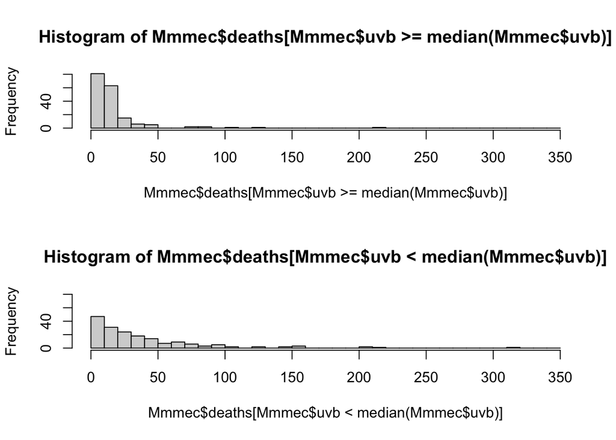

```r
par(mfrow = c(2, 1)) #tell R to plot two graphs below each other in one figure
hist(Mmmec$deaths[Mmmec$uvb >= median(Mmmec$uvb)], xlim = c(0, 350), ylim = c(0, 80), breaks = 10*(0:35)) #histogram for high UVB
hist(Mmmec$deaths[Mmmec$uvb < median(Mmmec$uvb)], xlim = c(0, 350), ylim = c(0, 80), breaks = 10*(0:35)) #histogram for low UVB
```

```r
par(mfrow = c(1, 1)) # set back to original setting
```

Now we will try some modelling on the malignant melanoma deaths dataset.

5. Fit a Poisson regression model for deaths, regressed on a main effect of uvb. The model can be obtained using `glm()`. Choose the correct family. Use the argument `offset = log(expected)`. Call the model `pmod0`. Is the estimated effect of UVB radiation on the number of malignant melanoma deaths in each county from pmod0 positive or negative?

```r
pmod0 <- glm(deaths ~ uvb, family = poisson, data = Mmmec, offset = log(expected))
summary(pmod0)
```

```
##
## Call:
## glm(formula = deaths ~ uvb, family = poisson, data = Mmmec, offset = log(expected))
##
## Deviance Residuals:
##     Min       1Q   Median       3Q      Max
## -8.2085  -1.5821  -0.3556   0.9032   9.4314
##
## Coefficients:
##              Estimate Std. Error z value Pr(>|z|)
## (Intercept) -0.070104   0.011047  -6.346 2.21e-10 ***
## uvb         -0.057191   0.002677 -21.364  < 2e-16 ***
## ---
## Signif. codes:  0 '***' 0.001 '**' 0.01 '*' 0.05 '.' 0.1 ' ' 1
##
## (Dispersion parameter for poisson family taken to be 1)
##
##     Null deviance: 2357.3  on 353  degrees of freedom
## Residual deviance: 1852.5  on 352  degrees of freedom
## AIC: 3451.5
##
## Number of Fisher Scoring iterations: 4
```

The linear effect of UVB dose seems to be negative

6. Fit a Poisson regression model for deaths, regressed on a main effect of uvb, and including a random intercept for region. Use the same offset as pmod0. Use function `glmer()`, and call this model `pmod1`. Is the estimated effect of UVB radiation on the number of malignant melanoma deaths in each county from pmod1 positive or negative?

```r
pmod1 <- glmer(deaths ~ uvb + (1|region), family = poisson, data = Mmmec, offset = log(expected))
summary(pmod1)
```

```
## Generalized linear mixed model fit by maximum likelihood (Laplace
##   Approximation) [glmerMod]
##  Family: poisson  ( log )
## Formula: deaths ~ uvb + (1 | region)
##    Data: Mmmec
##  Offset: log(expected)
##
##      AIC      BIC   logLik deviance df.resid
##   2256.4   2268.0  -1125.2   2250.4      351
##
## Scaled residuals:
##     Min      1Q  Median      3Q     Max
## -3.6593 -0.7340 -0.0528  0.6122  4.2276
##
## Random effects:
##  Groups Name        Variance Std.Dev.
##  region (Intercept) 0.1697   0.4119
## Number of obs: 354, groups:  region, 78
##
## Fixed effects:
##             Estimate Std. Error z value Pr(>|z|)
## (Intercept) -0.13859    0.04934  -2.809 0.004971 **
## uvb         -0.03443    0.01002  -3.435 0.000593 ***
## ---
## Signif. codes:  0 '***' 0.001 '**' 0.01 '*' 0.05 '.' 0.1 ' ' 1
##
## Correlation of Fixed Effects:
##     (Intr)
## uvb 0.047
```

The linear effect of UVB dose still seems to be negative.

7. Compare the fit of pmod0 and pmod1 using the AIC.

```r
AIC(pmod0, pmod1)
```

```
##       df      AIC
## pmod0  2 3451.545
## pmod1  3 2256.400
```

pmod1 is clearly preferable

8. Based on the likelihood ratio test, do you prefer pmod0 or pmod1? Use the method from exercise 1k. You will need to explicitly ask for the maximum log likelihood, using the function logLik.

```r
d0 <- -2*logLik(pmod0) #-2LL pmod0
d1 <- -2*logLik(pmod1) #-2LL pmod1
ldif <- d0 - d1 #-2LL difference
degfr <- 1 #number of extra parameters
pchisq(ldif, degfr, lower.tail = FALSE)/2 #p-value
```

```
## 'log Lik.' 1.272422e-262 (df=2)
```

The -2LL of pmod1 is significantly closer to 0 (p << 0.05), therefore pmod1 is preferable.

1. Fit a model similar to pmod1, but also including a random slope for uvb within each region. Call this model pmod2. Use anova() to compare pmod1 and pmod2. Which model do you prefer?

```r
pmod2 <- glmer(deaths ~ uvb + (uvb|region), family = poisson, data = Mmmec, offset = log(expected))
```

```
## boundary (singular) fit: see ?isSingular
```

```r
anova(pmod1, pmod2)
```

```
## Data: Mmmec
## Models:
## pmod1: deaths ~ uvb + (1 | region)
## pmod2: deaths ~ uvb + (uvb | region)
##       npar    AIC    BIC  logLik deviance Chisq Df Pr(>Chisq)
## pmod1    3 2256.4 2268.0 -1125.2   2250.4
## pmod2    5 2257.4 2276.7 -1123.7   2247.4 3.026  2     0.2202
```

The difference in -2LL is not significant (p = 0.22), therefore the model with less parameters is preferable, which is pmod1.